# Acidification

Frederik Rask Dalby

2025-04-22

There are many ways to model acidification and here a few examples are given. Lets use standard pig parameters for the first example and use a pH of 6 to simulate continuous acidifcation

```r
devtools::load_all("..")
```

```
## ℹ Loading ABM
## Indlæser krævet pakke: deSolve
```

```r
library(ggplot2)

out <- cbind(abm(), treatment = 'contr')
```

```
## rain = 1.9 kg/m2/day
## evaporation = 0.25 kg/m2/day
```

```r
outa <- cbind(abm(add_pars = list(pH = 6)), treatment = 'pH 6')
```

```
## rain = 1.9 kg/m2/day
## evaporation = 0.25 kg/m2/day
```

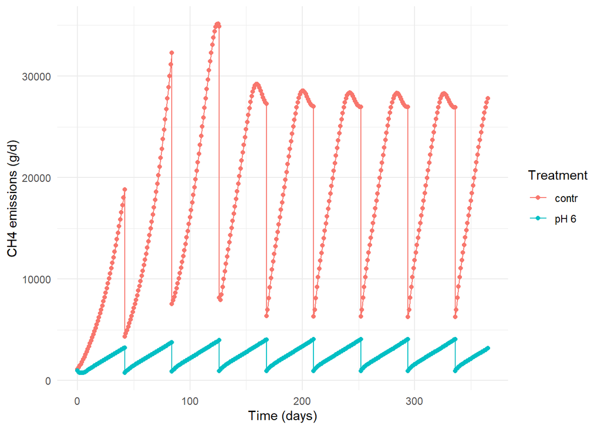

```r
dat <- rbind(out,outa)

ggplot(dat, aes(time, CH4_emis_rate, col = treatment)) + geom_line() +
  geom_point() +
  labs(x = 'Time (days)',
       y = 'CH4 emissions (g/d)',
       col = 'Treatment') +
  theme_minimal()
```

In this case the inhibition is due to the different inhibition factors in the model. These are NH4, NH3, VFA and H2S inhibition. The pH itself is not inhibiting methanogenic activity. Lets look into what is actually causing inhibition. With the current settings all methanogen groups are equally susceptible to inhibition, so we will just pick m0 as example.

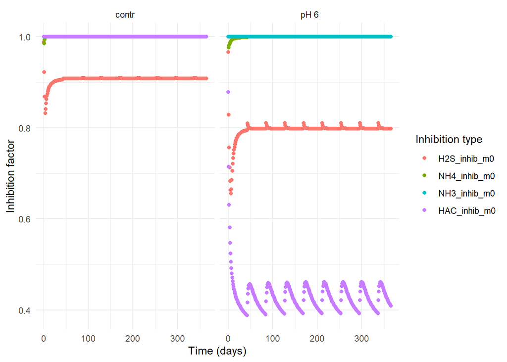

```r
library(data.table)

setDT(dat)
dat_long <- melt(dat, measure.vars = c('H2S_inhib_m0','NH4_inhib_m0','NH3_inhib_m0','HAC_inhib_m0'))


ggplot(dat_long, aes(time, value, col = variable)) + geom_point()+ facet_wrap(~treatment) +
  labs(x = 'Time (days)',
       y = 'Inhibition factor',
       col = 'Inhibition type') +
  theme_minimal()
```

So from this plot it is clearly protonated VFAs (HAC_inhib) that cause most of the inhibition. H2S also inhibits, even in the control section! Now we try another approach, where we can choose that we use a pH inhibition factor instead. In this case the model is not sensitive to the individual compounds above, only the pH value itself. When only pH inhibition factor is used it is equivalent to the cumulative inhibition (cum_inhib in the model output) and we see that HAC_inhib is now 1

```r
outb <- cbind(abm(add_pars = list(pH = 6), pH_inhib_overrule = TRUE), treatment = 'pH 6, pH overrule')
```

```
## rain = 1.9 kg/m2/day
```

```
## evaporation = 0.25 kg/m2/day
```

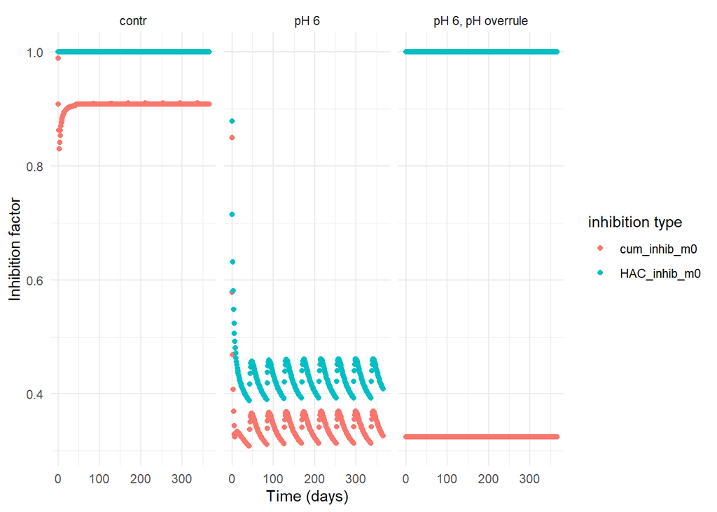

```r
dat <- rbind(dat, outb)
dat_long <- melt(dat, measure.vars = c('cum_inhib_m0','HAC_inhib_m0'))

ggplot(dat_long, aes(time, value, col = variable)) + geom_point() + facet_wrap(~treatment) +
  labs(x = 'Time (days)',
       y = 'Inhibition factor',
       col = 'inhibition type') +
  theme_minimal()
```

Predicted emission from these two approaches are very similar, but that might not be the case in some scenarios.

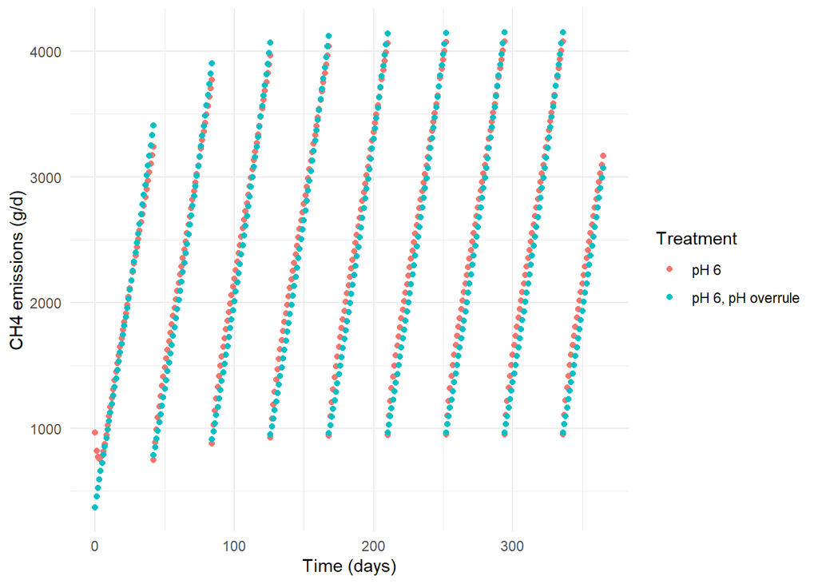

```r
ggplot(dat[treatment != 'contr'], aes(time, CH4_emis_rate, col = treatment)) + geom_point() +
  labs(x = 'Time (days)',
       y = 'CH4 emissions (g/d)',
       col = 'Treatment') +
  theme_minimal()
```

When using H2SO4 as acidification agent, the reduction in methane emission may not only be due to inhibition, but for example also competition for substrate between sulfate reducers and methanogens. We may want a way to simulate this, by also adjusting the sulfate concentration, thereby favoring sulfate reducer activity. From the built-in function H2SO4_titrat() we can estimate how much H2SO4 is approximately needed to reach a pH value of 6.

```r
conc_SO4 <- H2SO4_titrat(pH = 6, class_anim = 'pig')
print(paste('the concentration of SO4-S in the fresh manure is approximately', conc_SO4$cSO4))
```

```
## [1] "the concentration of SO4-S in the fresh manure is approximately 1.1819880527"
```

OK, so we will use this information in the simulation by setting the concentration in the freshly produced manure to that amount.

```r
outc <- cbind(abm(add_pars = list(conc_fresh.sulfate = conc_SO4$cSO4)), treatment = 'SO4 adjust only')
```

```
## rain = 1.9 kg/m2/day
```

```
## evaporation = 0.25 kg/m2/day
```

```r
outd <- cbind(abm(add_pars = list(conc_fresh.sulfate = conc_SO4$cSO4, pH = 6)), treatment = 'pH 6 + SO4 adjust')
```

```
## rain = 1.9 kg/m2/day
## evaporation = 0.25 kg/m2/day
```

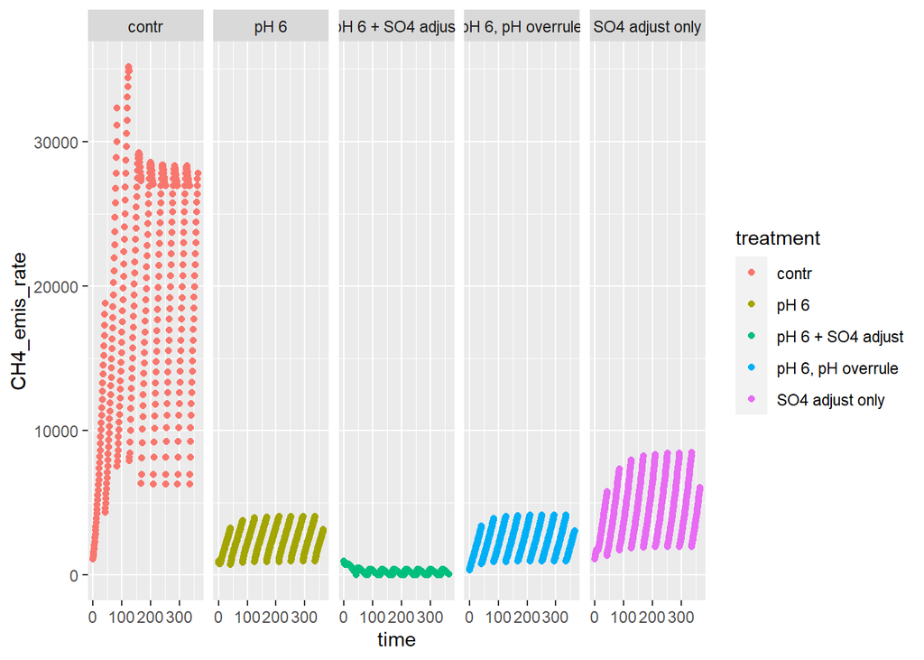

```r
dat <- rbind(dat, outc, outd)

ggplot(dat, aes(time, CH4_emis_rate, col = treatment)) + geom_point() + facet_grid(~treatment)
```

```r
  labs(x = 'Time (days)',
       y = 'CH4 emissions (g/d)',
       col = 'Treatment') +
  theme_minimal()
```

So just by changing the sulfate concentration we see an effect that is almost as large as the other approaches, and when combining sulfate addition and the effects of pH change we get a larger effect. Lets see what causes this.

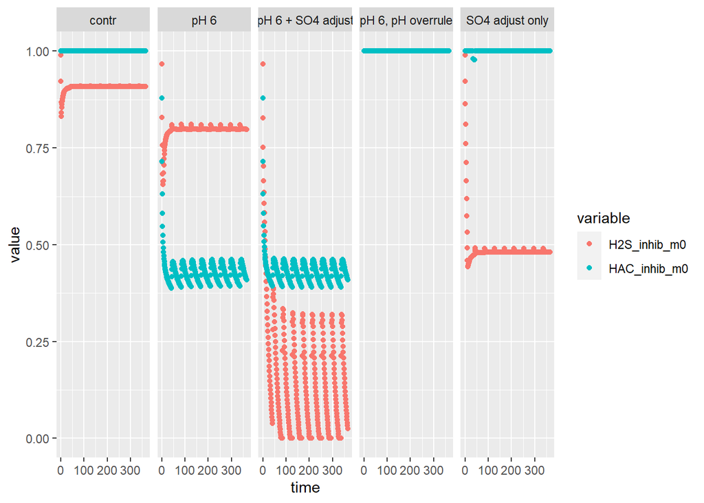

```r
dat <- rbind(dat, outc, outd)
dat_long <- melt(dat, measure.vars = c('H2S_inhib_m0','HAC_inhib_m0'))
ggplot(dat_long, aes(time, value, col = variable)) + geom_point() + facet_grid(~treatment)
```

```r
  labs(x = 'Time (days)',
       y = 'Inhibition factor',
       col = 'Inhibition type') +
  theme_minimal()
```

When only sulfate is added, H2S inhibition is more important because sulfate reducers reduce sulfate to sulfide! On the other hand HAC_inhibition is not present anymore, probably because the sulfate reducers also consume VFA quicker, reducing its concentration below its lower inhibition threshold. The rut_meth and rut_sr are measures of the substrate utilization rate and are directly proportional to the amount of methane and sulfide produced. Lets see what happens here.

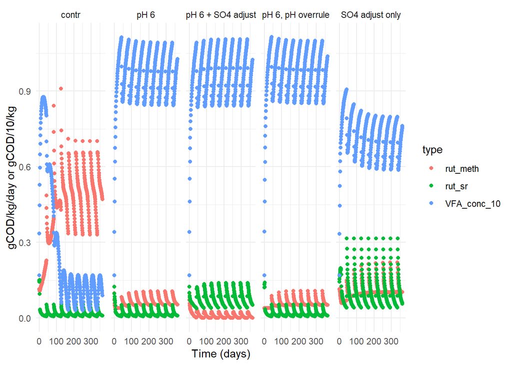

```r
dat$rut_meth <- (dat$rut_m0 + dat$rut_m1 + dat$rut_m2)/dat$slurry_mass
dat$rut_sr <- dat$rut_sr1/dat$slurry_mass
dat$VFA_conc_10 <- dat$VFA_conc/10
dat_long <- melt(dat, measure.vars = c('rut_meth','rut_sr','VFA_conc_10'))
ggplot(dat_long, aes(time, value, col = variable)) + geom_point() + facet_grid(~treatment) +
  labs(x = 'Time (days)',
       y = 'gCOD/kg/day or gCOD/10/kg',
       col = 'type') +
  theme_minimal()
```

With only sulfate added, sulfate reducers are equally active to the methanogens and VFA levels are lower, but when pH is reduced to 6 at the same time, sulfate reducers outcompete the methanogens, because their inhibition thresholds are a little different than the methanogens.